# Getting similar texts

Max Callaghan

2023-10-16

We know how to calculate the similarity of texts from our data frame, but how do we get information about which texts we are comparing

We first need to make sure we give each item in our dataframe a unique ID which we can use to identify it.

```r
library(readr)
df <- read_csv("data/uk_manifestos.csv")
df$id <- as.character(seq(1,length(df$text)))
df
```

```
## # A tibble: 5,240 × 5
##    text                                              cmp_c…¹ eu_code party id
##    <chr>                                               <dbl> <lgl>   <chr> <chr>
##  1 This election is about the crisis of living stan…     503 NA      Labo… 1
##  2 and the climate and environmental emergency.          501 NA      Labo… 2
##  3 Whether we are ready or not, we stand on the bri…     501 NA      Labo… 3
##  4 We must confront this change while dealing with …     503 NA      Labo… 4
##  5 Labour led the UK Parliament in declaring a clim…     501 NA      Labo… 5
##  6 The next Labour government will lead the world i…     501 NA      Labo… 6
##  7 The climate crisis ties us all into a common fat…     501 NA      Labo… 7
##  8 This election is our best hope to protect future…     501 NA      Labo… 8
##  9 The Intergovernmental Panel on Climate Change ha…     501 NA      Labo… 9
## 10 The Tories wasted a decade serving the interests…     501 NA      Labo… 10
## # … with 5,230 more rows, and abbreviated variable name ¹cmp_code
```

To make it easier to access data using ids later, we can create a corpus object, and tell quanteda to use our ID column as the names of the documents

```r
library(quanteda)
corp <- corpus(df)
docnames(corp) <- df$id
```

We can pass this corpus object to our usual functions for creating a document feature matrix, then calculate the similarity matrix.

```r
library(quanteda.textstats)
dfmat <- corp %>% tokens(remove_punc=TRUE) %>%
  tokens_remove(pattern=stopwords("en")) %>%
  dfm() %>%
  dfm_trim(min_termfreq=5) %>%
  dfm_tfidf()

sim_mat <- textstat_simil(dfmat, method="cosine", min_simil=-1)
sim_df <- as.data.frame(sim_mat, diag=TRUE, upper=TRUE)
```

We define an index for the text we want to find similar texts to, and get the similarity comparisons that compare to that document. After sorting and taking the first 5 documents, we can merge (left_join) with our original dataset using the id column.

```r
target_text <- 1335
print(df$text[target_text])
```

```
## [1] "Labour will give the people the final say on Brexit."
```

```r
library(dplyr)
similar_docs <- sim_df %>% filter(document1==target_text) %>%
  arrange(desc(cosine)) %>%
  head(5) %>%
  left_join(df, by=c("document2"="id"))

similar_docs
```

```
##   document1 document2    cosine
## 1      1335      1335 1.0000000
## 2      1335      1412 0.7894603
## 3      1335      1339 0.6606204
## 4      1335      1383 0.6561439
## 5      1335      1385 0.5608794
##                                                                                                    text
## 1                                                  Labour will give the people the final say on Brexit.
## 2                    Most importantly, under a Labour government, you will get the final say on Brexit.
## 3 Only a Labour government will put this decision in the hands of the people to give you the final say.
## 4                                                      Only Labour will deliver a final say referendum.
## 5                                               This final say referendum will not be a re-run of 2016.
##   cmp_code eu_code  party
## 1    202.1      NA Labour
## 2    202.4      NA Labour
## 3    202.1      NA Labour
## 4    202.4      NA Labour
## 5    202.4      NA Labour
```

## Embeddings

Let’s embed the documents and plot them.

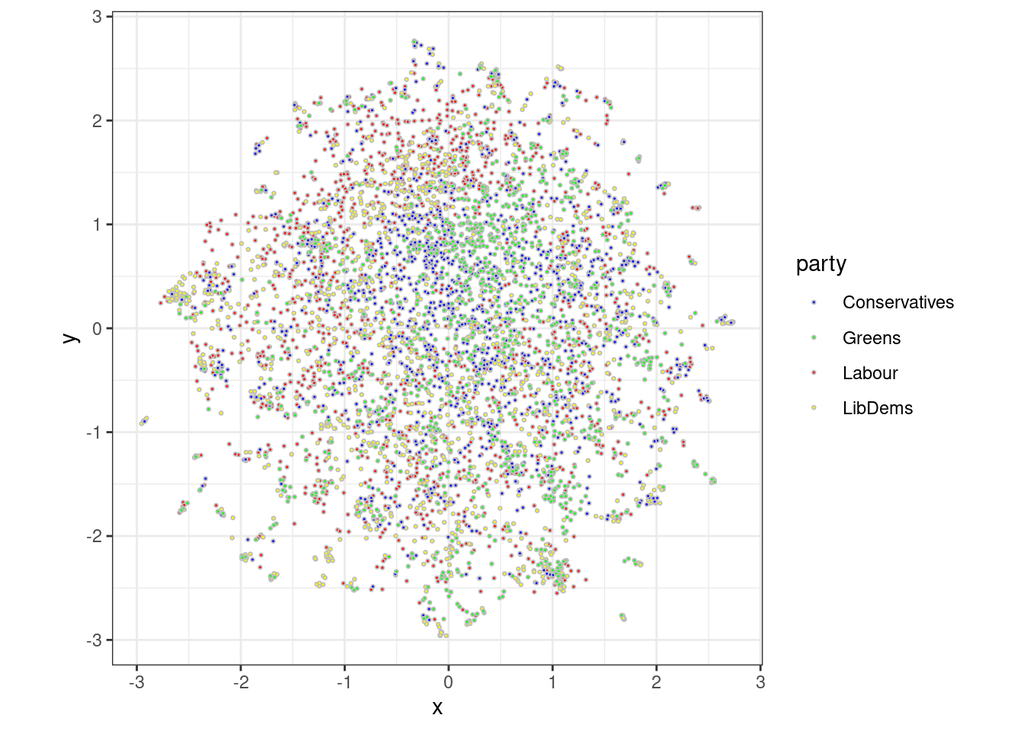

```r
library(uwot)
library(lsa)
library(ggplot2)

embeddings <- umap(as.matrix(dfmat))

df$x <- embeddings[,1]
df$y <- embeddings[,2]

colordict <- c(
  "Labour"="red","LibDems"="yellow",
  "Conservatives"="Blue","Greens"="green")

p <- ggplot(df, aes(x, y, fill=party)) +
  geom_point(color="grey", shape=21, size=0.5) +
  scale_fill_manual(values=colordict) +
  theme_bw() +
  coord_fixed()
p
```

We can compare the same documents in our embedding space by calculating the cosine similarity, but this has little meaning in our embedding space, as all documents that are one a single straight line will have a similarity of 1. Euclidean distance tells us how far apart the points are in the 2 dimensional space.

```r
print(df$text[target_text])
```

```
## [1] "Labour will give the people the final say on Brexit."
```

```r
dist_matrix <- as.matrix(dist(embeddings))

for (i in 1:nrow(similar_docs)) {
  comp_id <- as.numeric(similar_docs[i,"document2"])
  comp_text <- df$text[comp_id]
  multi_sim <- similar_docs[i,"cosine"]
  embed_sim <- cosine(embeddings[target_text,], embeddings[comp_id,])

  writeLines(paste0(
    "\nDocument: ",
    comp_text,
    "\nmultidimensional cosine similarity: ",
    round(multi_sim,2),
    "\nembedding cosine similarity: ",
    round(embed_sim,2),
    "\nembedding euclidean distance:  ",
    round(dist_matrix[target_text,comp_id],2)
  ))
}
```

```
##
## Document: Labour will give the people the final say on Brexit.
## multidimensional cosine similarity: 1
## embedding cosine similarity: 1
## embedding euclidean distance:  0
##
## Document: Most importantly, under a Labour government, you will get the final say on Brexit.
## multidimensional cosine similarity: 0.79
## embedding cosine similarity: 1
## embedding euclidean distance:  0.01
##
## Document: Only a Labour government will put this decision in the hands of the people to give you the final say.
## multidimensional cosine similarity: 0.66
## embedding cosine similarity: 1
## embedding euclidean distance:  0.02
##
## Document: Only Labour will deliver a final say referendum.
## multidimensional cosine similarity: 0.66
## embedding cosine similarity: 1
## embedding euclidean distance:  0.05
##
## Document: This final say referendum will not be a re-run of 2016.
## multidimensional cosine similarity: 0.56
## embedding cosine similarity: 1
## embedding euclidean distance:  0.13
```

If we plot the documents in the embedded space, colouring according to how similar they are to our target document in the multidimensional space, we can see that similar documents are indeed rather closer together.

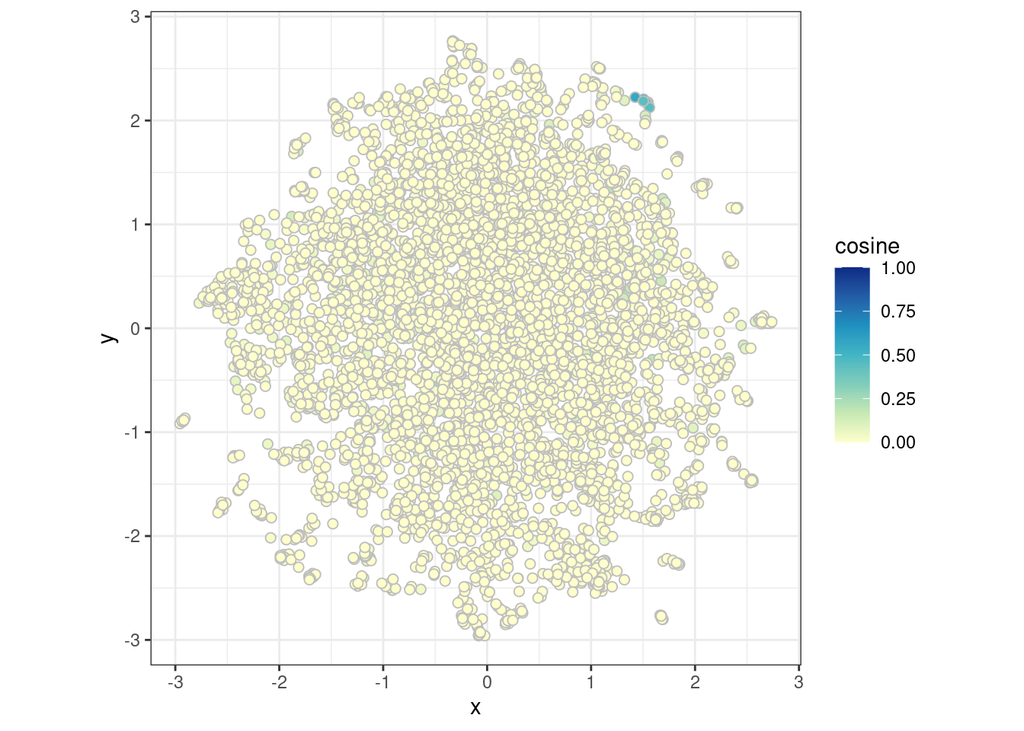

```r
target_sim_df <-  sim_df %>% filter(document1==target_text) %>%
  arrange(desc(cosine)) %>%
  left_join(df, by=c("document2"="id"))

p <- ggplot(target_sim_df, aes(x, y, fill=cosine)) +
  geom_point(color="grey", shape=21, size=2) +
  scale_fill_distiller(palette="YlGnBu", direction = 1) +
  theme_bw() +
  coord_fixed()
p
```